# Uncertainty Quantification on Graph Data

Calibrating uncertainty is of paramount importance for various models in practical settings(healthcare, agriculture, mining, mobility, ...). Various uncertainty types (monosonance, dissonance, consonance, vagueness, vacuity, entropy, aleatoric & epistemic uncertainty) can be leveraged to analyze models properties and behaviors. In this post, we'll see how to quantify uncertainty for semi-supervised learning on graph data using the following uncertainty types (dissonance, vacuity, entropy, aleatoric & epistemic uncertainty)[1]

## I. Introduction

Quantifying uncertainty has been overlooked in various practical scenarios and there have been misinterpretations of uncertainties in various settings(mobility, healthcare, agriculture, ...). Graph Neural Networks (GNNs) have been popularized lately in the machine learning community however despite their success, they did not account for various types of uncertainties in their modeling or behaviors. Various approaches for predicting uncertainty using bayesian neural networks have been explored for various tasks (classification, regression, ...) in various applications (CV, NLP, ...), based on aleatoric and epistemic uncertainty. Aleatoric uncertainty refers to data uncertainty from statistical randomness while Epistemic uncertainty indicates model uncertainty due to limited knowledge in collected data. There have been recent trends in modeling various types of uncertainty beyond aleatoric and epistemic uncertainty. Firstly in the belief or evidence theory domain, Subjective logic considers vacuity as uncertainty in subjective opinion. Additionally, other uncertainty types such as dissonance, consonance, vagueness, and monosonance have been discussed based on subjective logic to measure them based on their different root causes. In this blog post, we use Deep learning and belief and evidence theory domains to calibrate multidimensional uncertainty types for various tasks (node-level classification, misclassification detection, and out-of-distribution detection).

In the deep learning literature, there has been a focus on aleatoric and epistemic uncertainty using bayesian neural networks for the aforementioned tasks. aleatoric uncertainty consists of homoscedastic uncertainty (constant errors with different inputs) and heteroscedastic uncertainty (different errors with different inputs). For modeling aleatoric and epistemic uncertainty in regression and classification tasks, a deep learning framework was unveiled to calibrate them. Several methods have been proposed, Firstly distributional uncertainty was defined based on a distributional mismatch between the training and testing data distributions. Secondly, Dropout variational inference was used for approximate inference in Bayesian neural networks leveraging epistemic uncertainty. Other methods have considered the overall uncertainty in node classification. However, no prior work has considered uncertainty decomposition in Graph Neural Networks (GNNs)

There has been some exploratory work in the belief or evidence theory domain about uncertainty reasoning such as Fuzzy logic, Dempster-Shafer-Theory, or Subjective Logic. Belief theory emphasizes on reasoning inherent uncertainty in information caused by unreliable, incomplete, deceptive, or conflicting evidence. Subjective Logic considered predictive uncertainty in subjective opinions in terms of vacuity (lack of evidence) and vagueness (failing in classifying a belief state). More recently other types of uncertainty have been studied, for example, dissonance caused by conflicting evidence. Evidential deep learning was used with subjective logic to train a deterministic neural network for supervised classification in computer vision based on square loss. However, it did not consider a general approach for estimating multidimensional uncertainty or graph structure[1].

## II. Methods

We start with the propability distribution of a multinomial opinion :

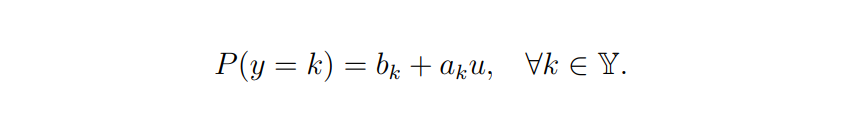

Where b is belief mass distribution, u is the uncertainty mass representing vacuity of evidence and a is the base rate distribution

The dirichlet PDF can be defined by :

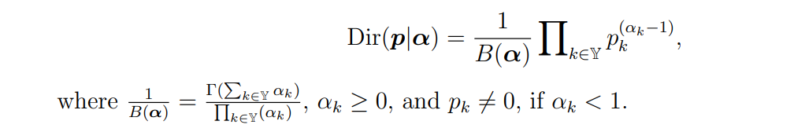

The expected probability distribution can be calculated with :

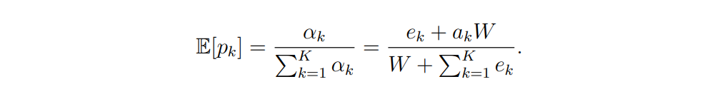

The observed evidence in a Dirichlet can be computed with:

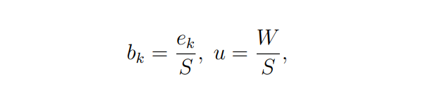

The measure of disonance can be calculated with :

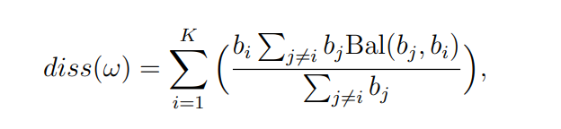

The epistemic uncertainty can be estimated with mutual information:

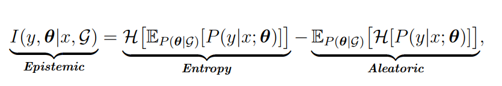

The first term indicates entropy that represents the total uncertainty while the second term is aleatoric that indicates data uncertainty

The conditional probability distribution can be obtained with :

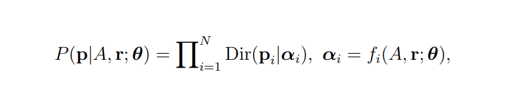

The joint class probability of y can be estimated with:

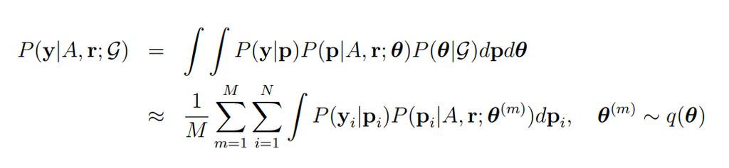

The bayes risk can be computed with a loss function:

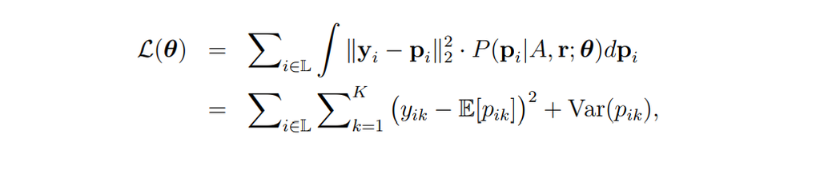

The contribution of evidence estimation for node j from training node i is obtained by:

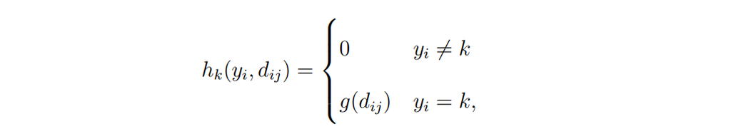

The evidence contribution for node i and training node l can be computed with:

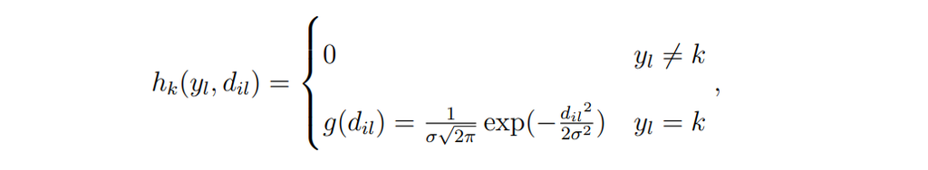

The prior evidence can be estimated by:

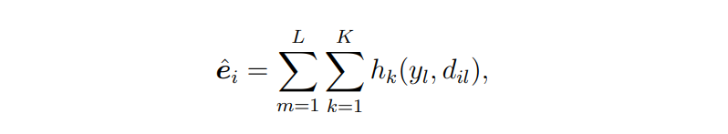

The total evidence is estimated by :

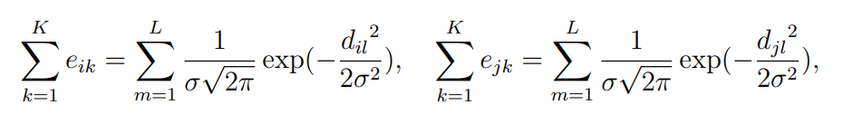

The vacuity values for node i and node j are :

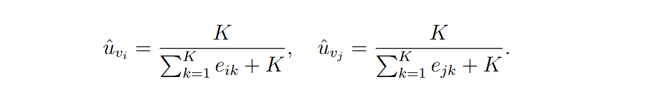

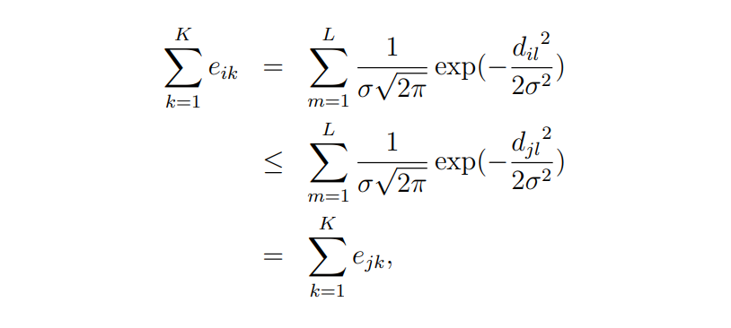

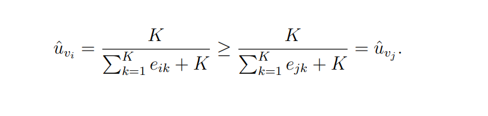

The final loss function can be obtained by :

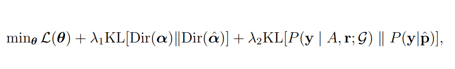

The final algorithm is obtained with the following steps:

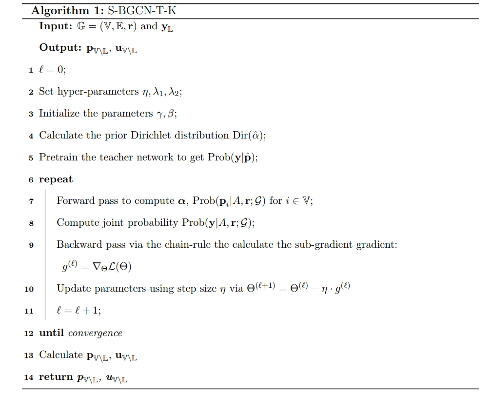

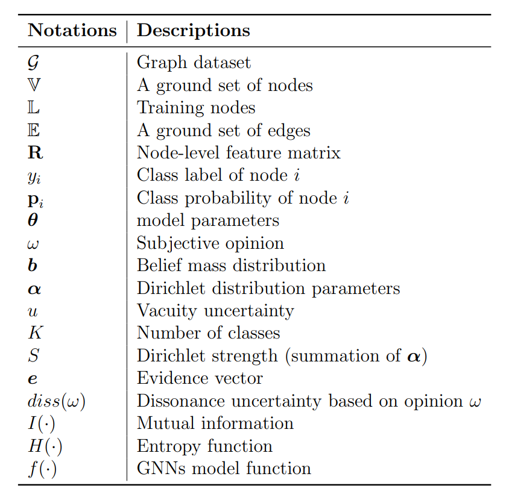

## III. References

1. Xujiang Zhao. Multidimensional Unceratinty Quantification For Deep Neural Networks. Arxiv, 2023